# Chapter_4

# Chapter 4 - Why Normal distributions are normal

We start with a coin flip and movement example. Line up 1000 people on the center of a football field, have them flip a coin over and over. For each heads they get they step to the left of the midline, for each tails they step to the right of the midline. While we can’t predict how far any given individual will have stepped in either direction, we can 100% predict the distribution of distances across those 1000 people. It will be roughly normally distributed. This is, more or less I think, because of the maximum entropy principle. Most people will on average not move, because there are so many permutations of some number of flips that sum to 0 when we can move one step left or one step right. There are slightly fewer that sum to 1 step left or 1 step right. There are slightly fewer still that sum to 2 steps, and so on. Thus even when the process is binomial, we can summarize its outcomes with a normal distribution.

## 4.1.1 - Normal by Addition

So we simulate the coin flip example using R, 16 steps between 1 and -1, replicated across 1000 of our supposed friends. When we sum the 16 steps and plot those 1000 sums, they are ALWAYS normally distributed. So why?

The core logic has to do with random draws from any distribution. Every draw represents a random deviation from the underlying mean. The more draws we have the more likely it is some of those deviations will cancel each other out. So on average, most sets will almost completely cancel out so that, by definition, on average everyone is near the mean. But some will not and so we see the characteristic bell curve for those sums. Thus addition of results from any underlying distribution (we used the uniform distribution for this) will always be Gaussian.

To carry this further, there are many many ways to cancel out positive or negative deviations. But there are very few ways (ie permutations of our events) that yield large negative or positive sums. Thus we see our inevitable Gaussian. So that brings us back to the max entropy perspective. Our central values make the fewest assumptions about our underlying events that constitute the sums. Large values can only be made by many steps in one direction or a few large steps with few small steps in the opposite. So you can think of it like, there is an equal probability of any given permutation. But permutations can have the same sum. And as we move closer to the center, we have more and more permutations that have the same sum - thus, given they are all equally probable, we would expect certain sums to appear much more frequently. So the normal distribution emerges. Heck yeah.

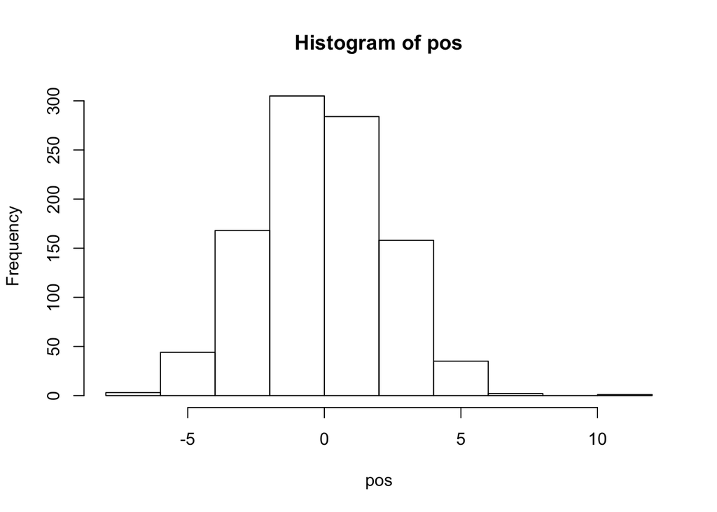

```r
#setion 4.1.1 - Normal by addition

#simulating the coin toss and step example for explaining the normal distribution.

#16 coin flips, steps between -1 and 1, 1000 people doing it. Always normal.
pos <- replicate(1000, sum(runif(16, -1,1)))

hist(pos)
```

## 4.1.2 - Normal by multiplication

Now we look at multiplicative effects. Frame story is multiple loci affecting a growth rate, and each has a multiplicative effect with the others. When we sample 12 of them from 1 to 1.1 and multiply them, then replicate 10,000 times, we find that our growth rates are normally distributed around 1.8ish? Let’s find out why! Cause I genuinely don’t know so.

AHH FUCK it’s because in this example, the multiplicative elements are quite small. Multiplying numbers with small differences ain’t all that different from adding them, and so we could actually substitute a sort of additive approximation. Wonder if this breaks down then if differences, e.g. effects of each multiplicative element are larger, even if still roughly equal?

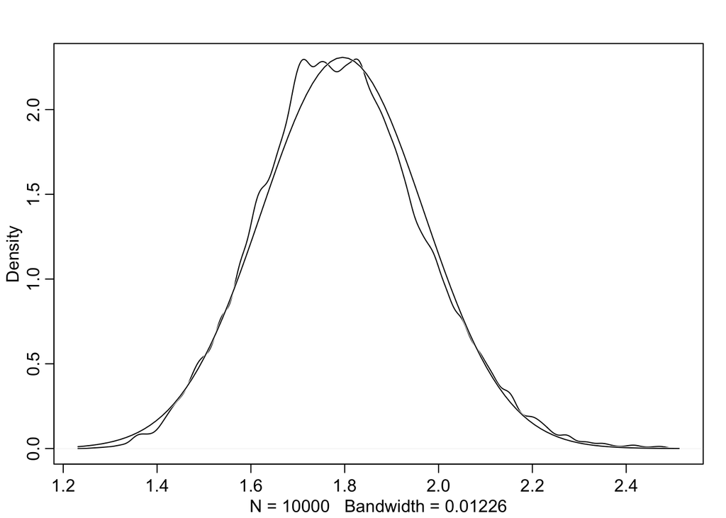

```r
#section 4.1.2 - Normal by multiplication

#looking at how multiplicative effects rather than additive effects


#example here is multiplicative effects of genes on growth rate. So we sample 12 growth rates from 1 to 1.1, where 1
#indictes no growth and 1.1 indicates a 10% increase. We then multiply these loci together. We replicate 10000 times and
#plot, and find rates are roughly nomrally distributed.
growth <- replicate(10000, prod(1+runif(12,0,0.1)))
dens(growth, norm.comp = T)
```

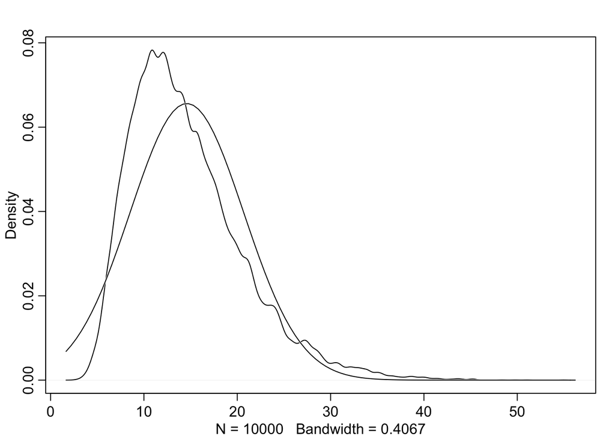

```r
#now let's test with larger effects.

big <- replicate(10000, prod(1+runif(12, 0,0.5)))
dens(big, norm.comp = T)
```

```r
#AHHH so it's not normally distributed now punk! This makes sense though, based on McElreath's explanation. We see that
#since effects are larger now, multiplying them deviates from an additive process much more strongly. Thus we lose the
#normally distributed pattern. But I fucking bet if we log transform this shit it's normal again ayyy??
```

## 4.1.3 Normal by log multiplication

Unsurprisingly, while larger effects do not produce Gaussian distributions when just multiplied together, they are normally distributed when multiplied together on a log scale. Collapsing those differences as ever, such that we could represent them as additive processes without too much loss.

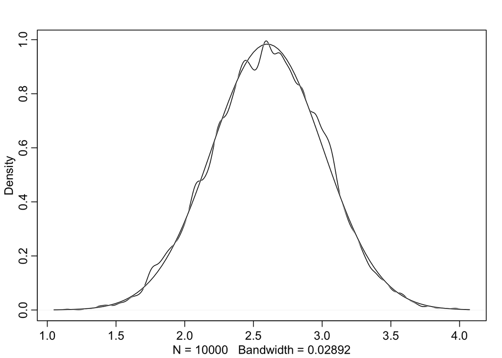

```r
log.big <- replicate(10000, log(prod(1+runif(12,0,0.5))))
dens(log.big, norm.comp = T)
```

## 4.1.4 Justifying Uses of Normal Distribution

We are going to justify using normal distributions as the basis for damn near all models using both ontological and epistemological reasoning. No idea why that’s important but hey let’s see where he goes with this yeah?

### 4.1.4.1 Ontological Justification

Basically we argue here that we use the Normal distribution becasue it is incredibly common. By adding together deviations or fluctuations, which is what normal distributions do, we shed idiosyncratic information about processes. This means that normality is a solid approximation for many different types of process and can be used widely. All that normality requires is a mean and spread around that mean. So long as a process can be summarized sufficiently with those two components, normality will REIGN SUPREME.

There are of course other consistent patterns that are necessary for other data types - exponential distributions of waiting times, Poisson distributions of frequencies of counts, etc. All of these belong to the exponetial family of distributions and we’ll cover them later.

### 4.1.4.2 Epistemological Justification

The normal distribution has the loosest set of assumptions for the underlying process or data. Basically, it represents a specific ‘state of ignorance’ about our data or its underlying distrbution. If all we are comfortable saying about our data is it’s mean and variance (or that it has a mean and finite variance around that mean), then the normal distribution makes no additional assumptions. Thus it is the best reflection we have for our current understanding.

As we learn more about a given system, we may be able to make more justified assumptions and thus to make different choices about distributions. But so long as we have no additional assumptions, the normal distribution is the one that can be realized in the most ways without introducing unjustified constraints or parameters.

As ever, he points out that models are tools or golems. They do not define our assumptions about the system, we define their assumptions about inference. And so we need not be bound by the assumptions of the model in our understanding of the system. But it is good to keep those limitations in mind as we draw further conclusions etc.

#### Overthinking - Gaussian distribution

Not going to go into detail about his pdf vs pmf work here, but I will use this as an opportunity to talk a bit about the probability density function for a Gaussian. In particular the pi. e makes a bit more sense, and acts as a base that scales sigma. But pi is weirder. Basically it acts as our normalizing constant that ensures the area under the curve always sums to 1. To understand this, you have to understand the Gaussian integral:

$\int e^{-x^{2}} dx = \sqrt{\pi}$

So basically, we know that the total area under an exponential to the power of -x^2 = sqrt(pi). Thus we can standardize our area in the Gaussian by pi (along with 2 sigma) to guarantee that our pdf sums to 1 across its entire area.

Understanding the Gaussian integral?? that’s a whole other thing. Dont know that I can talk through that as it requires understanding of the relationship between e, volume of circles, pi, and I think some multivariate calculus. But hey that’s life right? Gotta be limited somewhere.

## 4.2 A Language for Describing Models

Laying out some basic linguistic conventions for describing models and data.

1. A set of measurements that we want to predict or understand are called ‘outcome’ variables.
2. For each of these observations, we define a likelihood function that describes the plausibility of individual data points. For linear models, this is always Gaussian.
3. Next we have observations we want to use to predict these outcomes. We call these predictors or predictor variables.
4. We relate the shape of the likelihood model to the predictor variables - its precise location and variance as well as other properties if it has them. Thus we can define all parameters of the likelihood model using our predictors.
5. Lastly, we choose priors for each of those parameters. These define the initial information on the state of the model.

Then we can write the model out in very mathy terms, like:

$outcome_{i} \sim Normal(\mu_{i}, \sigma)$

$\mu_{i} = \beta \times predictor_{i}$

$\beta \sim Normal(0,10)$

$\sigma \sim HalfCauchy(0,1)$

Very proud of myself for that very simple latex, but anyways. Here we say that our outcome is normally distributed around $\mu$ with variance $\sigma$. $\mu$ is then a function of our predictor times a coefficient $\beta$. The prior on $\beta$ is a normal distribution centered at 0 with a standard deviation of 10, while the prior on our variance is a Half Cauchy with 0 and 1 as the parameters. I don’t know what the parameters are for a half cauchy, should probably look that up? First is a location parameter $\mu$ and then a scale parameter $\sigma$. Basically like half of a normal distribution when parameterized this way.

Love that he lays out the ridiculousness (to some degree) of how we refer to regression, multiple regression, ANOVA, ANCOVA, etc. when in reality they are just extensions of this model structure. It’s always mapping an outcome onto predictors using some likelihood function. Love to see it.

### 4.2.1 Re-describing the globe tossing model

The example of tossing a globe to assess the proportion of water on said globe can be re-expressed in the language above:

$w \sim Binomial(n, p)$ $p \sim Uniform(0,1)$

Here we have a binomial likelihood mapping our outcomes, $w$ the number of tosses that come up water, onto $n$ samples (tosses) with a probability of water, $p$. The prior on $p$ is then set as a uniform distribution from 0 to 1.

Note that the $sim$ symbol implies that all of these are stochastic, which is to say that no outcome or probability drawn from the prior is known with certainty. There are more or less plausible results, but overall the system is probabilistic rather than deterministic.

#### Overthinking: From model to Bayes theorem

Coming from the model above, we can insert it into Bayes’ classic equation:

$Pr(p\mid w,n) = \frac{Binomial(w\mid n,p) Uniform(p\mid 0,1)}{\int Binomial(w\mid n,p) Uniform(p\mid 0,1)dp}$

This is effectively just our grid approximation from earlier. We calculate the likelihoods for each value on our grid, multiply by the prior, then divide by the sum of that across all values on the grid to get our posterior to sum to 1. Simple as calculus.

## 4.3 A Gaussian Model of Height

We are going to build a model of height using the data from Nancy Howell’s work on the !Kung San.

```r
data("Howell1")

d <- Howell1

str(d)
```

```
## 'data.frame':    544 obs. of  4 variables:
##  $ height: num  152 140 137 157 145 ...
##  $ weight: num  47.8 36.5 31.9 53 41.3 ...
##  $ age   : num  63 63 65 41 51 35 32 27 19 54 ...
##  $ male  : int  1 0 0 1 0 1 0 1 0 1 ...
```

Technically speaking, there are an infinite number of potential Gaussian distributions, with some mean and variance. We are interested then in finding the one that is most plausible given the data we have. What is the ‘best fit’ mean and variance that would be most likely to generate this data? And, in a Bayesian framework, how certain are we about those parameters?

The general form of our height model is just:

$h_{i} \sim Normal(\mu, \sigma)$

##### Rethinking: Independent and Identically Distributed

Basically, all of our models are going to assume that data within levels are iid, which is to say, they are independent draws from the same underlying distribution. So identically distributed, in that they come from a distribution with the same fixed parameters, but are independent draws from that distribution. An example of non-independence would be physical measurements of related individuals.

A truly great point here that this assumption - the model assumption of iid as defined by a likelihood function - is an epistemological assumption not an ontological one. It is a tool we use for our understanding, an approximation of reality - a small world assumption of the ‘golem’ we are building. It is not something inherently true about the world. Otherwise, we engage in what ET Jaynes called the ‘mind projection fallacy’ where we assume that our understanding of a thing, the structure we impose on it to understand it, must define the thing itself. Signs and signifiers y’all. Maps, territories, you know the drill.

Also a great point from Ch 1 about how many process models can correspond to the same statistical model. Really fucking me up here Rich, like honestly though, love it. Anyways, this is all to say, we end up with a Gaussian model and associated priors such that:

$h_{i} \sim Normal(\mu, \sigma)$ - Likelihood $\mu \sim Normal(178, 20)$ - Prior for $\mu$ $\sigma \sim Uniform(0,50)$ - Prior for $\sigma$

So the central value (mean) we chose for our prior on $\mu$, 178 cm, is literally just McElreath’s height, the idea being we choose a roughly average central value and then a wide variance. So the mean could range anywhere from 138 to 218 cm based on our 95% intervals with a standard deviation of 20 cm. So we have plenty of room to move within that but don’t assume it’s uniform, there are still more and less plausible values for mean height. Here we use some level of everyday ‘expertise’ to inform our prior. We can’t always do that obviously.

Now we’ll plot that prior to get an idea of what it is saying out the distribution of possible means - what means are plausible vs not plausible and so on - as this is what will inform the ‘completeness’ of our posterior sampling.

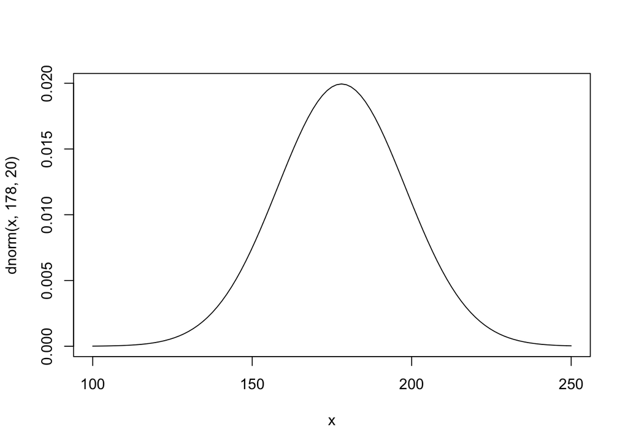

```r
curve( dnorm( x , 178 , 20) , from=100, to=250)
```

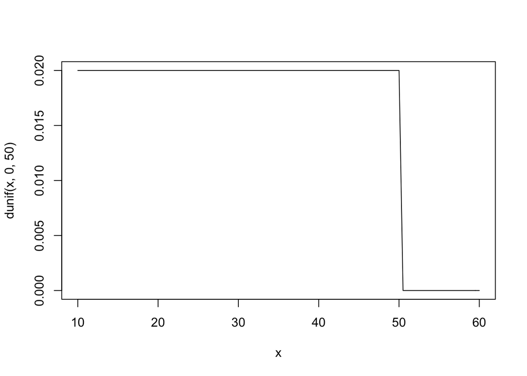

```r
curve( dunif( x , 0 , 50) , from=10 , to=60 )
```

Note that while our mean $\mu$ has a normal prior informed by human height, our sigma is uniform as heck - just a straight fuckin brick of probability from 0 to 50. What an absolute unit.

Now we want to sample from the prior. This is like sampling from our posterior before, but now looking just at what information we’ve not-so-tacitly coded into our priors.

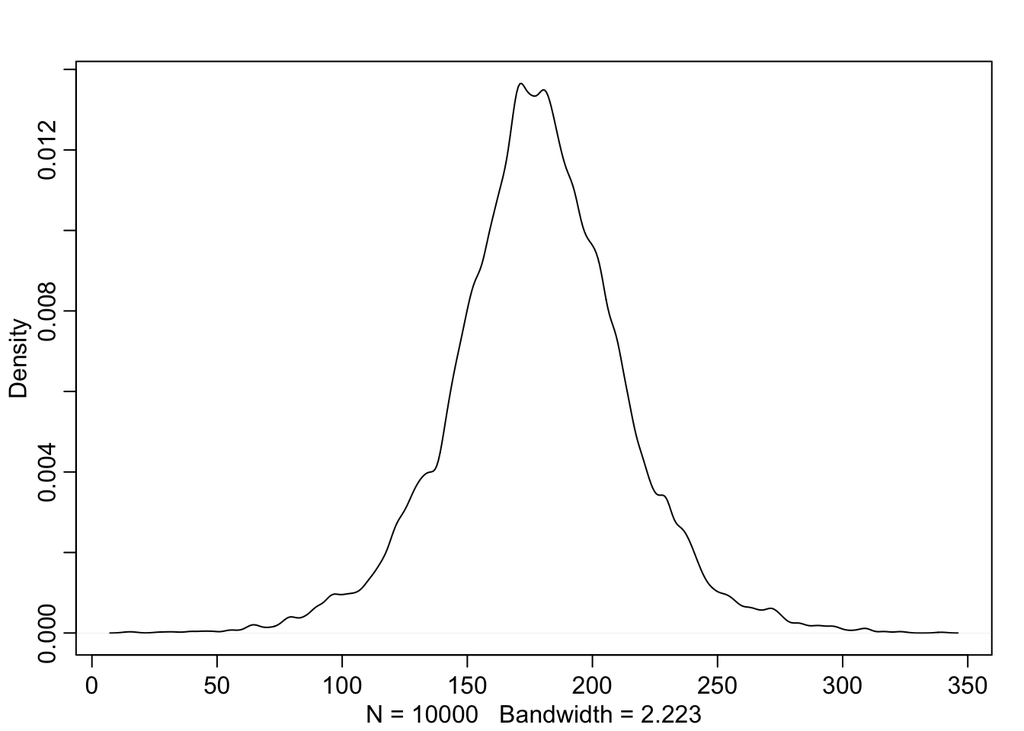

```r
sample_mu <- rnorm(1e4, 178, 20) #sample 10,000 means from our prior of 178,20
sample_sigma <- runif(1e4, 0,50) #sample 10,000 variances from our uniform prior, 0 to 50.

prior_h <- rnorm(1e4, sample_mu, sample_sigma) # so here I think we basically draw like...10,000 samples from each of our 10,000
#simulated parameterizations? Like we have two vectors of 10,000 mus and sigmas. We then sample 10,000 from each yeah? No, cuz it ends up still being 10,000 long it looks like, so it must just sample one from each then? Is that right? Doesn't seem to be much in terms of documentaiton of that behavior, so i'll just test it in the console.

#So yeah rnorm will draw a single point form each pair from the vectors. If you ask for more n than there are in each vector, it just
#loops back and starts again. So like, if I ask for 3 values, but i only provide 2 means and 2 variances, it gives me a draw from pair 1, then one from pair 2, then another from pair 1. Nice.

dens(prior_h)
```

This plot represents the expected distribution of heights, averaged over our prior. So basically, we draw 10,000 pairs of $\mu$ and $\sigma$ from the prior, then simulate a single data point from each of those 10,000 combinations. This gives us 10,000 draws from what are basically 10,000 different distributions informed by the priors we have set.

This seems like a very important idea for exploring how our priors impact our eventual inference I would think. If this seems to bias us towards specific values, then that’s probably v bad. by and large though, this seems pretty broad and sensible based on what we no a priori about human height.

##### Dropping $\epsilon$

McElreath notes that lots of texts teach regression based models in the basic algebraic form:

$h_{i} = \mu + \epsilon_{i}$ $\epsilon_{i} \sim Normal(0, \sigma)$

Where $\epsilon$ represents an error term that is normally distributed. While I don’t see a huge issue with that personally, he points out that this doesn’t generalize well to non-Gaussian models. So basically, when we want to work with like, a Binomial or Poisson model, then our $\epsilon$ doesn’t really do the job we need. So he opts for the more easily generalized notation:

$h_{i} \sim Normal(\mu, \sigma)$

Since we can just swap out Normal for whatever else we want and it remains roughly the same I think. Particularly because what we are really then doing is making $\mu$ or $\lambda$ or what have you a linear function of some predictors, which are then potentially transformed to the scale of our prediction - using the link function. So it gets us towards GLMs much quicker.

##### Overthinking: Model Definition to Bayes’ Theorem

Here we are just going to insert our parameter values from the priors into the actual Bayes equation, simple as can be:
$$Pr(\mu, \sigma \mid h) = \frac{\prod_{i}Normal(h_{i}\mid \mu,\sigma)Normal(\mu\mid 178,20)Uniform(\sigma\mid 0,50)}{\int\int\prod_{i}Normal(h_{i}\mid \mu,\sigma)Normal(\mu\mid 178,20)Uniform(\sigma\mid 0,50)d\mu d\sigma}$$

Once again, this looks a lil wild, but it’s really just pluggin in our priors. So basically, our posterior probability for a given parameter combination, given our data, ($Pr(\mu, \sigma \mid h)$) is equal to the likelihood of our data under that model ($Normal(h_{i}\mid \mu,\sigma)$) times the prior probability of those model parameters given our prior ($Normal(\mu\mid 178,20)Uniform(\sigma\mid 0,50)$). We then standardize that by the likelihood of our data given ANY parameterization of the current model structure, which is the denominator, just integrated our posterior over $\mu$ and $\sigma$.

Also worth noting, he points out that we are going to do the calculations on the log scale, so log likelihoods, which puts us into logarithmic addition rather than multiplication. Noice.